# delphi_forecasting_2025

## Delphi Forecasting Season 2024-25

### State level quantile forecasting of flu and covid hospitalizations (NHSN dataset)

#### Dmitry Shemetov & David Weber

help from Logan Brooks, Nat DeFries, Daniel McDonald, and Ryan Tibshirani.

2026-05-01

# Major Forecasting Challenges

- **non-stationarity** - varying vaccination rates, new strains, changing mobility patterns, superspreader events, etc.
- **large seasonal variation (flu)** - season start, duration, and peak size vary
- **lack of seasonal component (covid)** - seasonal pattern in the data is weak or inconsistent (post-pandemic)
- **data quality issues** - initial observations are incomplete, regular reporting delays, reporting errors, etc.
- **few seasons to train on** - NHSN data starts in 2020, the first two seasons are excluded because they were anomalous due to the pandemic, so effectively only 3 seasons of data are available for training

# The Data

Target: NHSN State level hospitalizations

## Recent Seasons Data: Flu

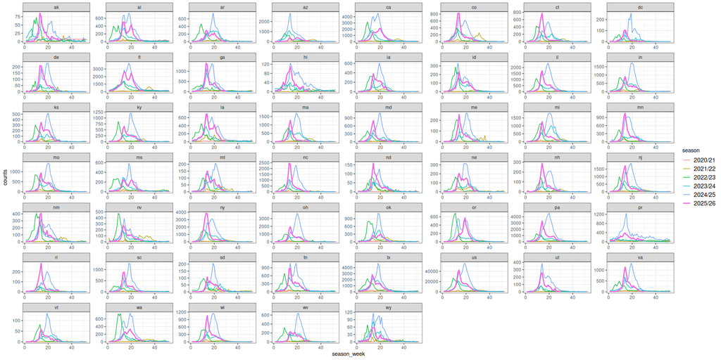

## Recent Seasons Data: Covid

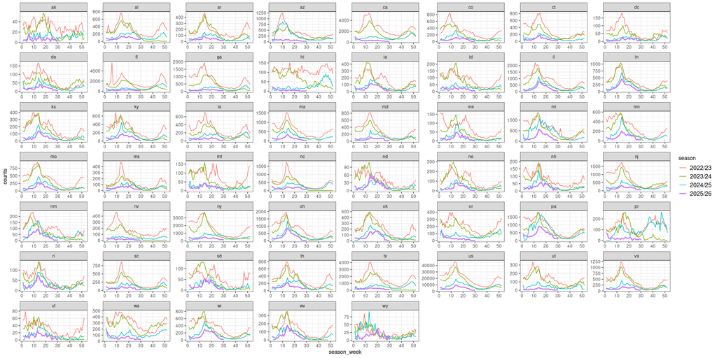

## Data Revisions: Flu

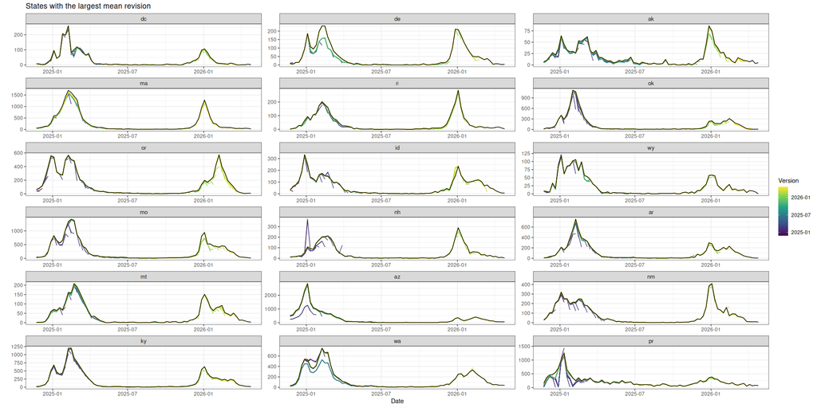

## Data Revisions: Covid

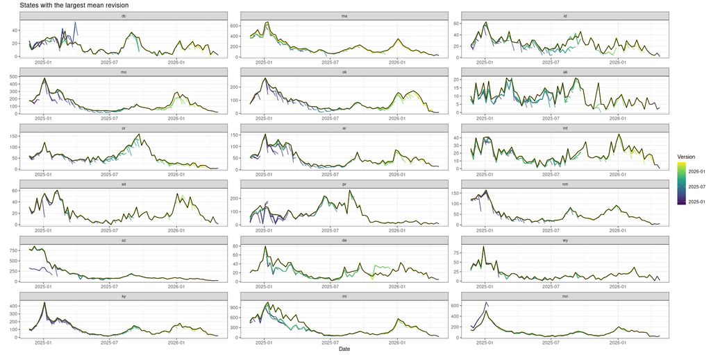

# Our Models

Ensembles of simpler forecasters

## Our Models: Baselines

- `linear`: linearly extrapolate the last 4 weeks, quantiles from the fit error
- `climate_base`: a climatological model, quantiles estimated from a 7 week period centered on the `target_date`’s season week from historical data for that geo
- `climate_linear`: a weighted ensemble of the climatological and linear, depending on the ahead and quantile

## Our Models: Baselines

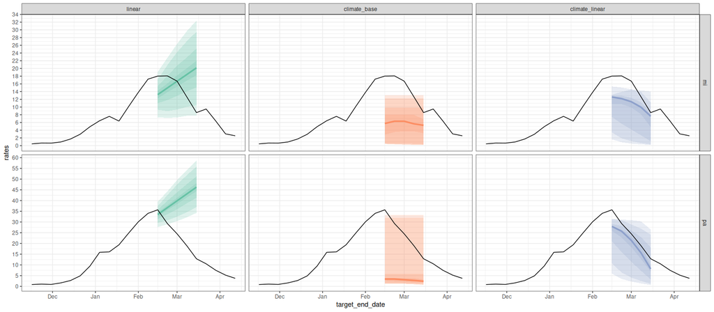

## Our Models: Autoregressive

`windowed_seasonal`: an AR model trained on data from the same seasonal window in previous years

$$x_{t+h} = a_0 + a_1 \cdot x_{t-7} + a_2 \cdot x_{t-14}$$

- $x$ is hospitalization rates, $t$ is the forecast date, $h$ is the horizon in days
- built using [epipredict](https://cmu-delphi.github.io/epipredict/)
- training data: 3 weeks before now through 5 weeks after the target date (-3/+8 from now)

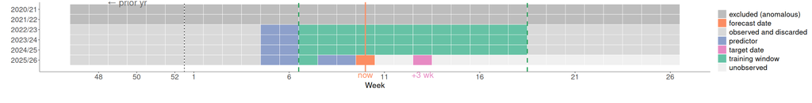

## Our Models: Autoregressive

For forecasting NSSP for either flu or covid, since it is a rate to begin with, we just use that 2 term autoregressive model, using all states as training data.

## Our Models: Autoregressive — Data Preprocessing

NHSN reports **counts**; we convert to **rates per 100k** before forecasting

For Flu, we also augment with ILI+ and FluSURV data (inspired by Flusion), then whiten on a per-geo+source basis:

To make these comparable, we normalize in several ways:

1. **Variance stabilization** — 4th root transform
2. **Scaling** — divide by the inter-quantile range (5th–95th percentile)
3. **Centering** — subtract so that the median is zero

## Our Models: Autoregressive with Exogenous Predictors

`windowed_seasonal_nssp`: adds NSSP emergency department visits as an exogenous predictor

$$x_{t+h} = a_0 + a_1 x_{t-7} + a_2 x_{t-14} + a_3 y_{t-7} + a_4 y_{t-14}$$

- $y$ is NSSP (ED visit rates) — a leading indicator for hospitalizations
- no whitening, no augmented sources (NSSP doesn’t go back far enough)
- same formulation for both Flu and Covid

## Our Models: Autoregressive — Fitting

We use **quantile regression** via [epipredict](https://cmu-delphi.github.io/epipredict/reference/quantile_reg.html), which wraps the standard [quantreg](https://rdrr.io/cran/quantreg/) package:

- Each quantile level $\tau$ is fit as a **separate weighted linear program**:

$$\mathop{\mathrm{minimize}}_{\beta} \sum_i w_i \cdot L(y_i,\, x_i^\top \beta)$$

- The **pinball loss** penalises under- and over-shoots asymmetrically:

$$L(y, t) := \begin{cases} (1-\tau)(t - y), & y < t \\ \tau(y - t), & y \geq t \end{cases}$$

## Our Models: Ensemble

Our submission (`CMU-TimeSeries`) is a **weighted ensemble** of the component models, with geo-level weights

- Weights are (nominally) set manually each week based on performance and data quality
- **2024/25**: initially relied heavily on `climate_linear` — the season started late and we were unsure of data quality. Eventually transitioned back to AR forecasters
- **2025/26**: almost exclusively `windowed_seasonal_nssp` (NSSP exogenous), with a small contribution from `windowed_seasonal` (the whitening AR) for Flu

## Infrastructure

**Pipeline**: weekly automated runs via [`targets`](https://docs.ropensci.org/targets/) + [`epipredict`](https://cmu-delphi.github.io/epipredict/)

- Each model variant is a target; `targets` skips recomputation when inputs haven’t changed
- Forecasts and scores uploaded to S3; rendered notebooks for review each week
- Use of make to handle shared environmental variables, submitting after manual checks and any adjustments

## Model Selection

**Exploration**: backtest over the 2023/24 season of versioned data with several model variants

- lags, up to 5 weeks back
- Exogenous sources: NSSP, NWSS, NWSS region, Veteran’s affairs, google symptoms
- Seasonal augmentation methods:
  - windowed (various sizes, {3, 5, 7} weeks × forward ∈ {1, 3, 5} weeks)
  - Aux signals:
    - seasonal sinusoid
    - PCA
    - climatological
- Residual whitening: on/off

## Flu: Sample Forecasts Rate Scale

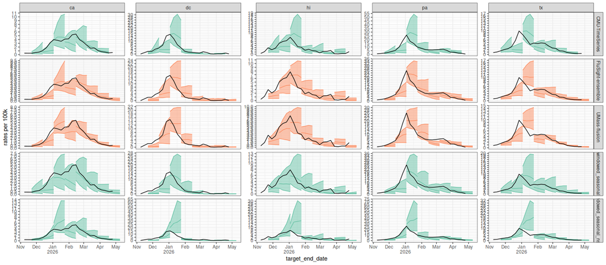

## Covid: Sample Forecasts Rate Scale

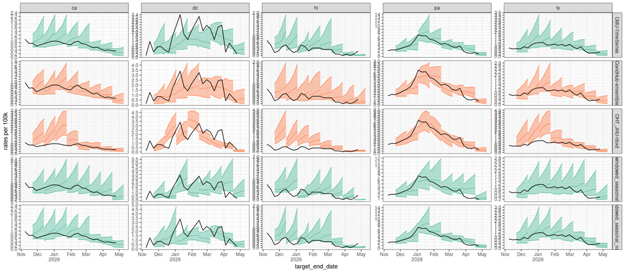

# Future Work

- **“Always decreasing” bias** — many forecasters underpredict during rising phases, especially for flu; root cause is data bias, possible fix is phase-specific models
- **Metrocasting** — city/county level forecasting for NSSP

# Future Work

- **Nowcasting / revision anticipation** — NHSN data is substantially revised in the weeks after initial release; a nowcasting model that anticipates these revisions could recover ~10% of forecast error

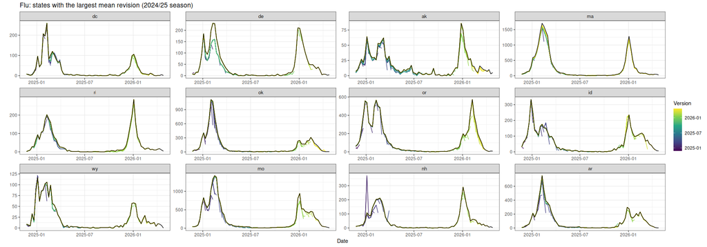